# Assignment 8

Cameron Kalik

### Data

Here is the head of the data frame for reference!

| name | publisher | gender | race | eyeColor | hairColor | height | weight | alignment | intelligence | strength | speed | durability | power | combat | total |
| --- | --- | --- | --- | --- | --- | --- | --- | --- | --- | --- | --- | --- | --- | --- | --- |
| A-Bomb | Marvel Comics | Male | Human / Radiation | yellow | No Hair | 203 | 441 | good | 38 | 100 | 17 | 80 | 17 | 64 | 316 |
| Abe Sapien | Dark Horse Comics | Male | Icthyo Sapien | blue | No Hair | 191 | 65 | good | 88 | 14 | 35 | 42 | 35 | 85 | 299 |
| Abin Sur | DC Comics | Male | Ungaran | blue | No Hair | 185 | 90 | good | 50 | 90 | 53 | 64 | 84 | 65 | 406 |
| Abomination | Marvel Comics | Male | Human / Radiation | green | No Hair | 203 | 441 | bad | 63 | 80 | 53 | 90 | 55 | 95 | 436 |
| Abraxas | Marvel Comics | Male | Cosmic Entity | blue | Black | 99 | 99 | bad | 88 | 100 | 83 | 99 | 100 | 56 | 526 |
| Agent Bob | Marvel Comics | Male | Human | brown | Brown | 178 | 81 | good | 10 | 8 | 13 | 5 | 5 | 20 | 61 |

### Correlations

```r
correlation <- cor(superheroData$height, superheroData$weight)
correlation
```

```
## [1] 0.1676003
```

```r
cor.test(superheroData$height, superheroData$weight)
```

```
##
##  Pearson's product-moment correlation
##
## data:  superheroData$height and superheroData$weight
## t = 2.6664, df = 246, p-value = 0.008175
## alternative hypothesis: true correlation is not equal to 0
## 95 percent confidence interval:
##  0.04395076 0.28619247
## sample estimates:
##       cor
## 0.1676003
```

```r
psych::corr.test(superheroData$height, superheroData$weight)
```

```
## Call:psych::corr.test(x = superheroData$height, y = superheroData$weight)
## Correlation matrix
## [1] 0.17
## Sample Size
## [1] 248
## These are the unadjusted probability values.
##   The probability values  adjusted for multiple tests are in the p.adj object.
## [1] 0.01
##
##  To see confidence intervals of the correlations, print with the short=FALSE option
```

I like the cor.test function the best since it gives the most information pertaining to the value of the correlation. Instead of just giving the value of the correlation, the function gives you a confidence interval that the correlation is between two values and a probability that the true correlation is equal to 0.

### Correlation Graphs

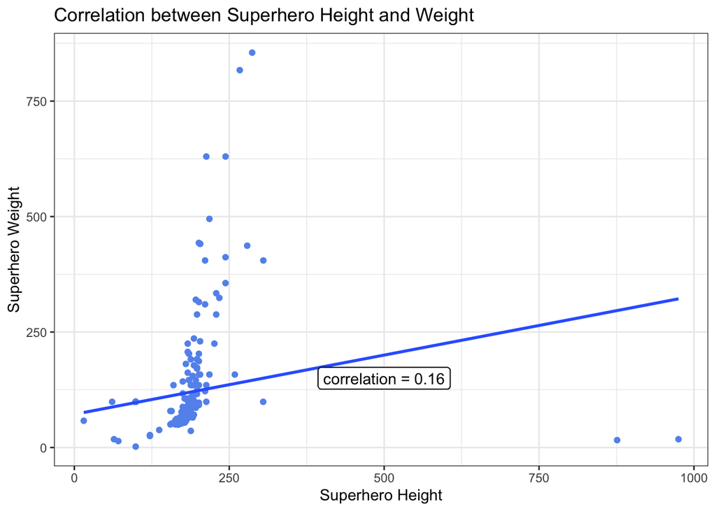

```r
ggplot(data = superheroData, aes(x = height, y = weight)) +
  geom_point(color = "cornflowerblue") +
  geom_smooth(method = "lm", se = FALSE) +
  theme_bw() +
  labs(x = "Superhero Height", y = "Superhero Weight", title = "Correlation between Superhero Height and Weight") +
   geom_label(x = 500,
                y = 150,
             label = "correlation = 0.16")
```

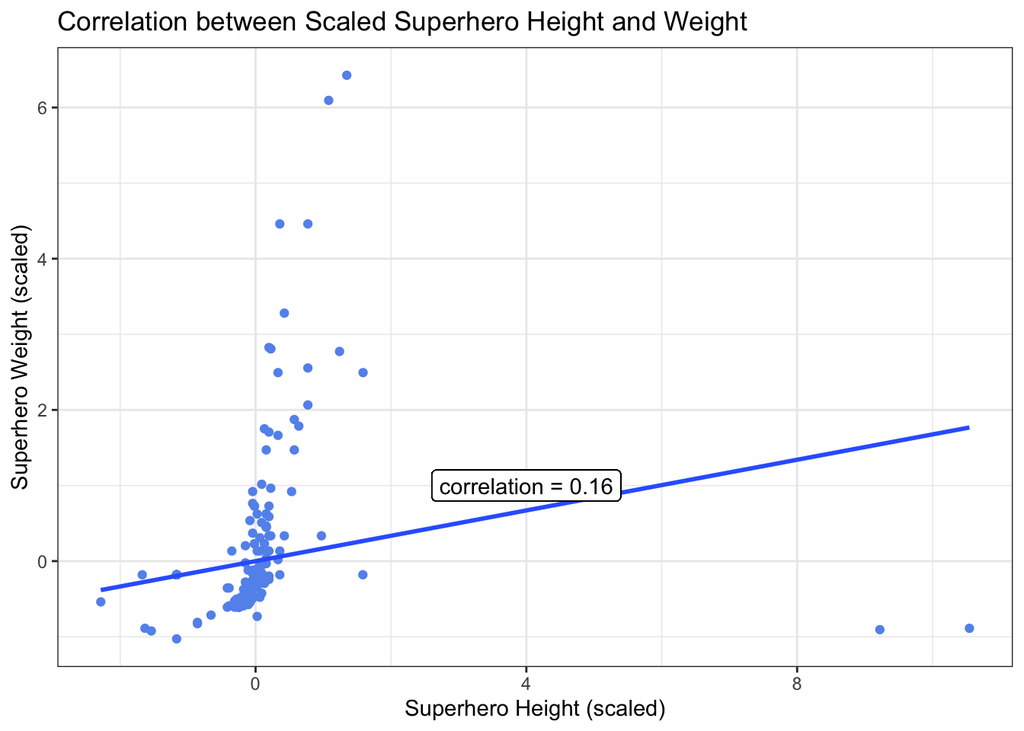

```r
#scale variables
superheroData$scaled_height <- scale(superheroData$height)
superheroData$scaled_weight <- scale(superheroData$weight)

ggplot(data = superheroData, aes(x = scaled_height, y = scaled_weight)) +
  geom_point(color = "cornflowerblue") +
  geom_smooth(method = "lm", se = FALSE) +
  theme_bw() +
  labs(x = "Superhero Height (scaled)", y = "Superhero Weight (scaled)", title = "Correlation between Scaled Superhero Height and Weight") +
   geom_label(aes(x = 4,
                y = 1),
             label = "correlation = 0.16") +
  xlim(min(superheroData$scaled_height), max(superheroData$scaled_height)) +
  ylim(min(superheroData$scaled_weight), max(superheroData$scaled_weight))
```

The line of best fit for both graphs representing the correlation between height and weight is the same. This is because the formula for correlation already standardizes the variables, so finding the correlation of two standardized variables will be the same as the correlation of two unstandardized variables.